# Intro To The Z Transform

```python
import numpy as np
import matplotlib.pyplot as plt
import IPython.display as ipd
```

Let's recall the equation for convolution

## $x*h[n] = \sum_{j=0}^{J-1} h[j]x[n-j] $

### Ex)

We showed in class how the following impulse response

$h[0] = 1$, $h[1] = 1$

leads to a "lowpass filter" which kills of higher frequencies. If we plug this into the equation for the convolution, we get the following equation for what the result is in terms of $x$, which is known as a **finite discrete difference equation**

### $y[n] = x[n] + x[n-1]$

Now let's make

### $x[n] = e^{i 2 \pi f n}$

where $f$ is in cycles per sample, and we know because of aliasing that the max $f$ can be is 0.5. But otherwise, unlike the DFT, $f$ can be a completely arbitrary real number, and it doesn't have to go through an integer number of cycles over any particular interval.

For convenience, let $\omega = 2 \pi f$, which means we consider $\omega \leq \pi$

Now let's plug this phasor, which is referred to as "z" ($z = e^{i \omega n}$), into the equation

### $y[n] = e^{i \omega n} + e^{i \omega (n-1)}$

Factoring out common terms, we get this

### $y[n] = e^{i \omega n}(1 + e^{-i \omega})$

I want to break this apart into an amplitude and a phase, and I want to look at the amplitude to verify that this promotes low frequencies. Use a trick where I multiply by a fancy 1, which is

## $ \frac{e^{i \omega/2}}{e^{i \omega/2}} $

## $y[n] = e^{i \omega n} \left( \frac{e^{i \omega/2} + e^{-i \omega/2}}{e^{i \omega/2}} \right) $

## $y[n] = e^{i \omega n/2} \left( e^{i \omega/2} + e^{-i \omega/2} \right) $

Now I can use an identity based on Euler's formula to change what's into the parentheses simply into a cosine

$e^{i x} = \cos(x) + i \sin(x)$

$e^{ix} + e^{-ix} = \cos(x) + i \sin(x) + \cos(-x) + i \sin(-x) = 2 \cos(x)$

## $y[n] = e^{i \omega n/2} 2 \cos(\omega/2) $

## $y[n] = e^{i \pi f n} 2 \cos(\pi f) $

We see that the amplitude plot is simply $2 \cos (\pi f)$. When we plot this, we indeed see that it falls off for higher frequencies

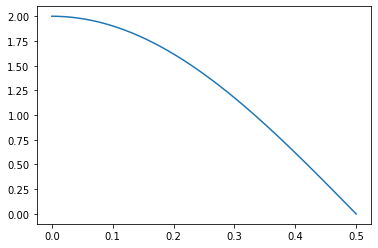

```python
f = np.linspace(0, 0.5, 1000)
amp = 2*np.cos(np.pi*f)
plt.plot(f, amp)
```